# Ground-Dwelling Natural Enemy Abundance and Diversity in Relation to Local Management and Landscape Heterogeneity in Okanagan Vineyards

Hannah Friesen

2026-03-24

## 1 SYSTEM INFO

```r
version
```

```
##                _
## platform       x86_64-w64-mingw32
## arch           x86_64
## os             mingw32
## crt            ucrt
## system         x86_64, mingw32
## status
## major          4
## minor          5.2
## year           2025
## month          10
## day            31
## svn rev        88974
## language       R
## version.string R version 4.5.2 (2025-10-31 ucrt)
## nickname       [Not] Part in a Rumble
```

## 2 SET UP

Loading packages required for the analysis

```r
# Load necessary libraries
library(here) # for loading data
library(tidyverse)
library(dplyr)
library(corrplot) # to test for correlation
library(car)
library(glmmTMB) # for GLMM modelling
library(lme4) # for LMM modellings
library(lmerTest)     # p-values for LMM fixed effects
library(DHARMa) # for residual diagnostics
library(ggplot2) # for figures
library(ggeffects)
library(ggfortify)
library(grateful) # for citing in Rmarkdown
library(vegan) # for species accumulation curves
library(broom.mixed)
library(officer)
library(kableExtra)
library(cowplot) # for figures
library(flextable) # for tables
```

create an output to cite the packages.

```
##  [1] "base"          "broommixed"    "car"           "corrplot"
##  [5] "cowplot"       "DHARMa"        "flextable"     "ggeffects"
##  [9] "ggfortify2016" "ggfortify2018" "glmmTMB2017"   "glmmTMB2025"
## [13] "here"          "kableExtra"    "knitr2025"     "knitr2015"
## [17] "knitr2014"     "lme4"          "lmerTest"      "officer"
## [21] "performance"   "rmarkdown2024" "rmarkdown2018" "rmarkdown2020"
## [25] "tidyverse"     "vegan"
```

## 3 CONTEXT

This research is exploratory and observational.

The four response variables are (i) spider abundance, (ii) spider family richness, (iii) carabid abundance, (iv) carabid species richness.

The predictor variables are (i) management type (conventional or organic), (ii) vegetation complexity (cover, height and species richness), (iii) proportion of natural area in surrounding landscape, (iv) habitat (vine row or inter row).

## 4 LOCAL AND LANDSCAPE FACTORS

### 4.1 Load Predictor Variable Datasets

Let’s load the local and landscape data and combine into one dataframe using site_ID.

```r
# Load predictor datasets and vineyard coordinates
sites <- read_csv(here("00_data", "vineyard_sites.csv"), show_col_types = FALSE)
veg <- read_csv(here("00_data", "veg_data_VY.csv"))
landscape <- read_csv(here("00_data", "landscape_metrics.csv"))
coords <- read_csv(here("00_data", "site_coordinates.csv"))

# Ensure coordinates are numeric
coords <- coords %>%
  mutate(site_ID = as.character(site_ID)) %>%
  mutate(
    long = as.numeric(unlist(long)),
    lat  = as.numeric(unlist(lat))
  )

# combine into one dataframe using site_ID
vineyard_sites_df <- sites %>%
  left_join(veg,  by = "site_ID") %>%
  left_join(landscape,  by = "site_ID") %>%
  drop_na()
```

### 4.2 Summarize Predictor Variables

Next we’ll summarize the proportion of natural areas in the surrounding 1000m landscape and distance to nearest natural area by management type.

```r
# Landscape summary
summary_landscape <- vineyard_sites_df %>%
  group_by(management_type) %>%
  summarise(
    n_sites        = n_distinct(site_ID),
    avg_natural    = mean(total_natural_1000, na.rm = TRUE),
    sd_natural     = sd(total_natural_1000, na.rm = TRUE),
    min_natural    = min(total_natural_1000, na.rm = TRUE),
    max_natural    = max(total_natural_1000, na.rm = TRUE),
    avg_distance_to_natural = mean(distance_to_natural, na.rm = TRUE),
    sd_distance_natural     = sd(distance_to_natural, na.rm = TRUE),
    min_distance_natural    = min(distance_to_natural, na.rm = TRUE),
    max_distance_natural    = max(distance_to_natural, na.rm = TRUE),
    .groups = "drop")

summary_landscape
```

| management_type | n_sites | avg_natural | sd_natural | min_natural | max_natural | avg_distance_to_natural | sd_distance_natural | min_distance_natural | max_distance_natural |
| --- | --- | --- | --- | --- | --- | --- | --- | --- | --- |
| conv | 22 | 36.02925 | 19.32029 | 10.868958 | 80.59201 | 62.56329 | 74.31342 | 0 | 289.3679 |
| org | 15 | 37.77022 | 18.29131 | 8.398438 | 60.59168 | 49.34041 | 40.71709 | 0 | 142.3203 |

```r
# save as table
write.csv(
  summary_landscape,
  here::here("02_tables", "summary_landscape.csv"),
  row.names = FALSE
)
```

Now let’s look at the local vegetation predictor variables by management type.

```r
# Compute summary statistics
summary_veg_table <- vineyard_sites_df %>%
  group_by(management_type, habitat) %>%
  summarise(
    veg_cover_mean   = mean(avg_veg_cover, na.rm = TRUE),
    veg_cover_sd     = sd(avg_veg_cover, na.rm = TRUE),

    veg_height_mean  = mean(avg_veg_height, na.rm = TRUE),
    veg_height_sd    = sd(avg_veg_height, na.rm = TRUE),

    veg_rich_mean    = mean(veg_richness, na.rm = TRUE),
    veg_rich_sd      = sd(veg_richness, na.rm = TRUE),
    .groups = "drop"
  )


# make table for thesis
summary_veg_clean <- summary_veg_table %>%
  tidyr::pivot_longer(
    cols = starts_with("veg_"),
    names_to = "Variable",
    values_to = "Value"
  ) %>%
  tidyr::separate(
    Variable,
    into = c("metric", "stat"),
    sep = "_(?=[^_]+$)"   # splits "veg_cover_mean" into "veg_cover" + "mean"
  ) %>%
  tidyr::pivot_wider(
    names_from  = c(management_type, habitat, stat),
    values_from = Value
  )

summary_veg_clean
```

| metric | conv_CR_mean | conv_CR_sd | conv_DR_mean | conv_DR_sd | org_CR_mean | org_CR_sd | org_DR_mean | org_DR_sd |
| --- | --- | --- | --- | --- | --- | --- | --- | --- |
| veg_cover | 27.163165 | 24.722914 | 62.93536 | 20.729281 | 71.18322 | 20.092019 | 77.44965 | 12.466415 |
| veg_height | 11.695329 | 7.861882 | 18.00060 | 10.761832 | 34.24698 | 16.988157 | 26.60602 | 15.565079 |
| veg_rich | 8.470588 | 5.052664 | 12.41176 | 4.328326 | 12.08333 | 3.999094 | 13.12500 | 4.204682 |

```r
# save as table
write.csv(
  summary_veg_clean,
  here::here("02_tables", "summary_veg_clean.csv"),
  row.names = FALSE
)
```

Next we’ll use line plots to visualize vegetation characteristics by location (vine row/ inter-row) and management

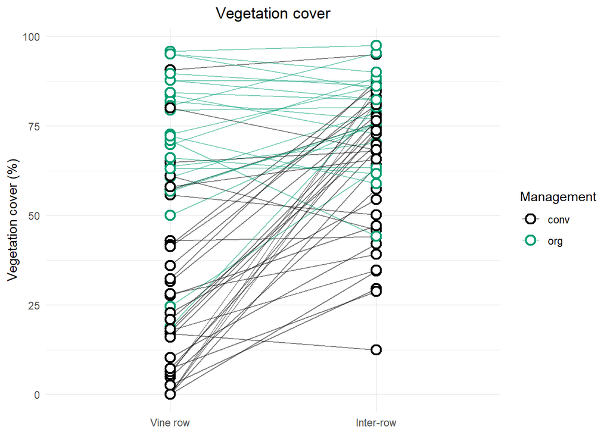

```r
# plot vegetation characteristics by location (vine row/ inter row) and management type
# let's use line plots to account for the paired design of vine rows/ interrows!
# average veg cover
veg_cover_mgmt <- ggplot(vineyard_sites_df, aes(x = habitat, y = avg_veg_cover, group = interaction(site_ID, year), color = management_type)) +
  geom_line(alpha = 0.5) +
  geom_point(
    aes(fill = management_type),
    shape = 21, size = 3, stroke = 1.2
  ) +
  scale_x_discrete(labels = c("CR" = "Vine row", "DR" = "Inter-row")) +
  scale_color_manual(values = c("conv" = "black", "org" = "#009E73")) +
  scale_fill_manual(values = c("conv" = "white", "org" = "white")) +
  labs(
    title = "Vegetation cover",
    x = NULL,
    y = "Vegetation cover (%)",
    color = "Management",
    fill = "Management"
  ) +
  theme_minimal() +
  theme(plot.title = element_text(hjust = 0.5))

veg_cover_mgmt
```

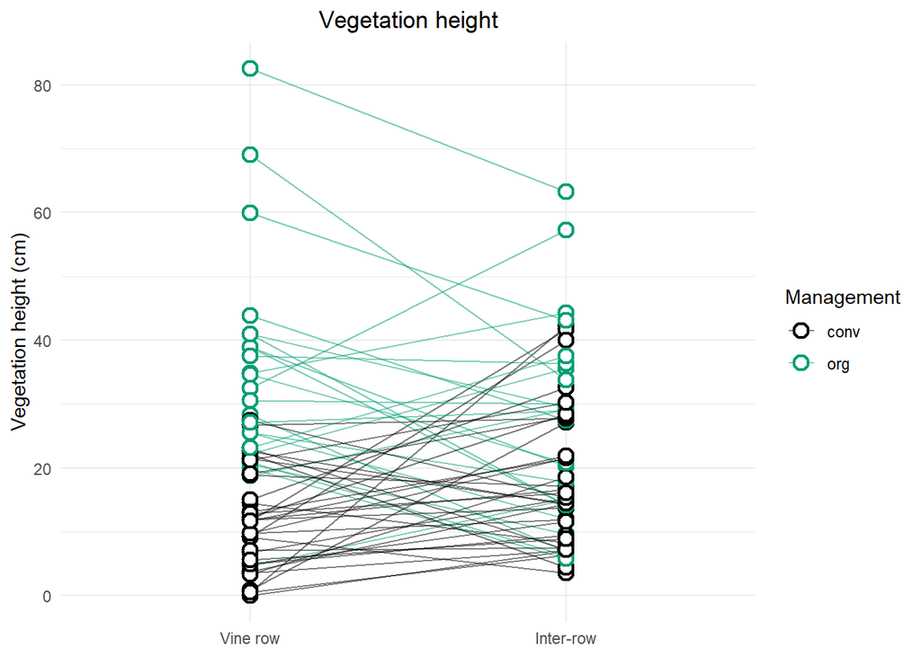

```r
# plot vegetation characteristics by location (vine row/ inter row) and management type
# let's use line plots to account for the paired design of vine rows/ interrows!
# average veg height
veg_height_mgmt <- ggplot(vineyard_sites_df, aes(x = habitat, y = avg_veg_height, group = interaction(site_ID, year), color = management_type)) +
  geom_line(alpha = 0.5) +
  geom_point(
    aes(fill = management_type),
    shape = 21, size = 3, stroke = 1.2
  ) +
  scale_x_discrete(labels = c("CR" = "Vine row", "DR" = "Inter-row")) +
  scale_color_manual(values = c("conv" = "black", "org" = "#009E73")) +
  scale_fill_manual(values = c("conv" = "white", "org" = "white")) +
  labs(
    title = "Vegetation height",
    x = NULL,
    y = "Vegetation height (cm)",
    color = "Management",
    fill = "Management"
  ) +
  theme_minimal() +
  theme(plot.title = element_text(hjust = 0.5))

veg_height_mgmt
```

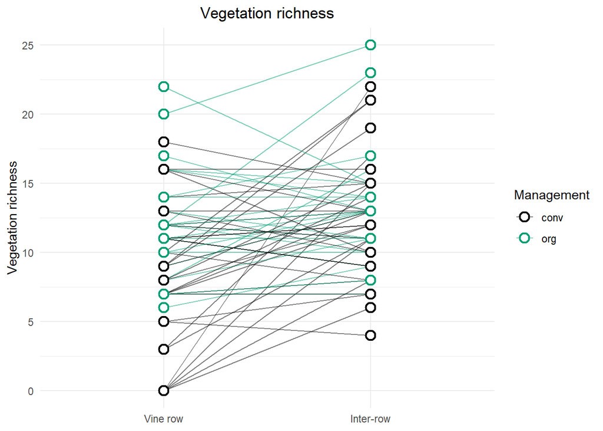

```r
# plot vegetation characteristics by location (vine row/ inter row) and management type
# let's use line plots to account for the paired design of vine rows/ interrows!
# veg richness
veg_richness_mgmt <- ggplot(vineyard_sites_df, aes(
  x = habitat,
  y = veg_richness,
  group = interaction(site_ID, year),
  color = management_type
)) +
  geom_line(alpha = 0.5) +
  geom_point(
    aes(fill = management_type),
    shape = 21, size = 3, stroke = 1.2
  ) +
  scale_x_discrete(labels = c("CR" = "Vine row", "DR" = "Inter-row")) +
  scale_color_manual(values = c("conv" = "black", "org" = "#009E73")) +
  scale_fill_manual(values = c("conv" = "white", "org" = "white")) +
  labs(
    title = "Vegetation richness",
    x = NULL,
    y = "Vegetation richness",
    color = "Management",
    fill = "Management"
  ) +
  theme_minimal() +
  theme(plot.title = element_text(hjust = 0.5))

veg_richness_mgmt
```

Vegetation cover, height and richness are on average higher in organic vineyards compared to conventional vineyards, with the greatest difference seen in the vine row. This makes sense, since many conventional vineyards use herbicide under the vine row.

### 4.3 Models for Vegetation Variables

Let’s use LMM’s to explore how vegetation properties vary by management type, habitat and year.

```r
# Make sure factors are set correctly
veg_VY_data <- vineyard_sites_df %>%
  mutate(
    management_type = factor(management_type),
    habitat         = factor(habitat),  # CR / DR
    year            = factor(year)
  )

# 1) Vegetation cover (%): LMM (Gaussian)
lm_cover <- lmer(
  avg_veg_cover ~ management_type + habitat + year + (1 | site_ID),
  data = veg_VY_data
)

# 2) Vegetation height (cm): LMM (Gaussian)
lm_height <- lmer(
  avg_veg_height ~ management_type + habitat + year + (1 | site_ID),
  data = veg_VY_data
)

# 3) Vegetation richness: LMM (Gaussian)
lm_rich <- lmer(
  veg_richness ~ management_type + habitat + year + (1 | site_ID),
  data = veg_VY_data
)

# Summaries
summary(lm_cover)
```

```
## Linear mixed model fit by REML. t-tests use Satterthwaite's method [
## lmerModLmerTest]
## Formula: avg_veg_cover ~ management_type + habitat + year + (1 | site_ID)
##    Data: veg_VY_data
##
## REML criterion at convergence: 1020.2
##
## Scaled residuals:
##      Min       1Q   Median       3Q      Max
## -2.05331 -0.77226 -0.02441  0.72299  2.30788
##
## Random effects:
##  Groups   Name        Variance Std.Dev.
##  site_ID  (Intercept)  51.3     7.163
##  Residual             419.9    20.491
## Number of obs: 116, groups:  site_ID, 37
##
## Fixed effects:
##                    Estimate Std. Error      df t value Pr(>|t|)
## (Intercept)          35.988      4.433  88.779   8.119 2.52e-12 ***
## management_typeorg   29.428      4.595  37.168   6.404 1.75e-07 ***
## habitatDR            23.563      3.805  83.429   6.192 2.13e-08 ***
## year2025             -4.458      4.065 102.848  -1.097    0.275
## ---
## Signif. codes:  0 '***' 0.001 '**' 0.01 '*' 0.05 '.' 0.1 ' ' 1
##
## Correlation of Fixed Effects:
##             (Intr) mngmn_ hbttDR
## mngmnt_typr -0.440
## habitatDR   -0.429  0.000
## year2025    -0.611  0.021  0.000
```

```r
summary(lm_height)
```

```
## Linear mixed model fit by REML. t-tests use Satterthwaite's method [
## lmerModLmerTest]
## Formula: avg_veg_height ~ management_type + habitat + year + (1 | site_ID)
##    Data: veg_VY_data
##
## REML criterion at convergence: 889.1
##
## Scaled residuals:
##     Min      1Q  Median      3Q     Max
## -1.8840 -0.5685 -0.1382  0.4813  2.9690
##
## Random effects:
##  Groups   Name        Variance Std.Dev.
##  site_ID  (Intercept)  43.87    6.623
##  Residual             112.94   10.627
## Number of obs: 116, groups:  site_ID, 37
##
## Fixed effects:
##                    Estimate Std. Error      df t value Pr(>|t|)
## (Intercept)          8.8725     2.6389 74.0417   3.362 0.001226 **
## management_typeorg  16.6310     3.0295 29.9236   5.490 5.89e-06 ***
## habitatDR            0.5344     1.9735 73.8654   0.271 0.787299
## year2025             8.6407     2.1738 92.6362   3.975 0.000139 ***
## ---
## Signif. codes:  0 '***' 0.001 '**' 0.01 '*' 0.05 '.' 0.1 ' ' 1
##
## Correlation of Fixed Effects:
##             (Intr) mngmn_ hbttDR
## mngmnt_typr -0.480
## habitatDR   -0.374  0.000
## year2025    -0.566  0.018  0.000
```

```r
summary(lm_rich)
```

```
## Linear mixed model fit by REML. t-tests use Satterthwaite's method [
## lmerModLmerTest]
## Formula: veg_richness ~ management_type + habitat + year + (1 | site_ID)
##    Data: veg_VY_data
##
## REML criterion at convergence: 655.5
##
## Scaled residuals:
##     Min      1Q  Median      3Q     Max
## -1.9041 -0.5902 -0.1628  0.6087  3.2208
##
## Random effects:
##  Groups   Name        Variance Std.Dev.
##  site_ID  (Intercept)  3.651   1.911
##  Residual             15.039   3.878
## Number of obs: 116, groups:  site_ID, 37
##
## Fixed effects:
##                    Estimate Std. Error      df t value Pr(>|t|)
## (Intercept)          7.2860     0.8993 79.1215   8.102 5.47e-12 ***
## management_typeorg   2.2690     0.9844 30.5096   2.305 0.028136 *
## habitatDR            2.7414     0.7201 75.5412   3.807 0.000284 ***
## year2025             2.7883     0.7824 96.5875   3.564 0.000570 ***
## ---
## Signif. codes:  0 '***' 0.001 '**' 0.01 '*' 0.05 '.' 0.1 ' ' 1
##
## Correlation of Fixed Effects:
##             (Intr) mngmn_ hbttDR
## mngmnt_typr -0.461
## habitatDR   -0.400  0.000
## year2025    -0.590  0.020  0.000
```

```r
# R2 (marginal = fixed effects only; conditional = fixed + random)
performance::r2(lm_cover)
```

```
## # R2 for Mixed Models
##
##   Conditional R2: 0.494
##      Marginal R2: 0.432
```

```r
performance::r2(lm_height)
```

```
## # R2 for Mixed Models
##
##   Conditional R2: 0.530
##      Marginal R2: 0.348
```

```r
performance::r2(lm_rich)
```

```
## # R2 for Mixed Models
##
##   Conditional R2: 0.362
##      Marginal R2: 0.208
```

Let’s make sure the residuals look okay

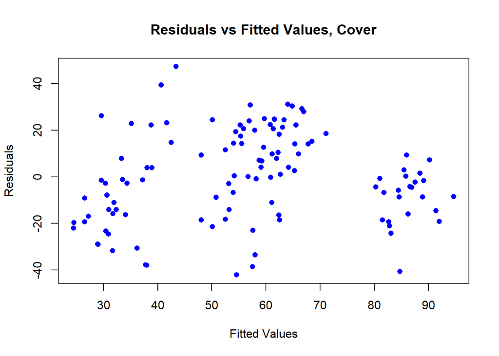

```r
# Calculate residuals
residuals_cover <- residuals(lm_cover)

#Calculate predicted
predicted_cover <- predict(lm_cover)

# Plot the ordinary residuals against the fitted values
plot(predicted_cover, residuals_cover,
     main = "Residuals vs Fitted Values, Cover",
     xlab = "Fitted Values",
     ylab = "Residuals",
     pch = 16, col = "blue")
```

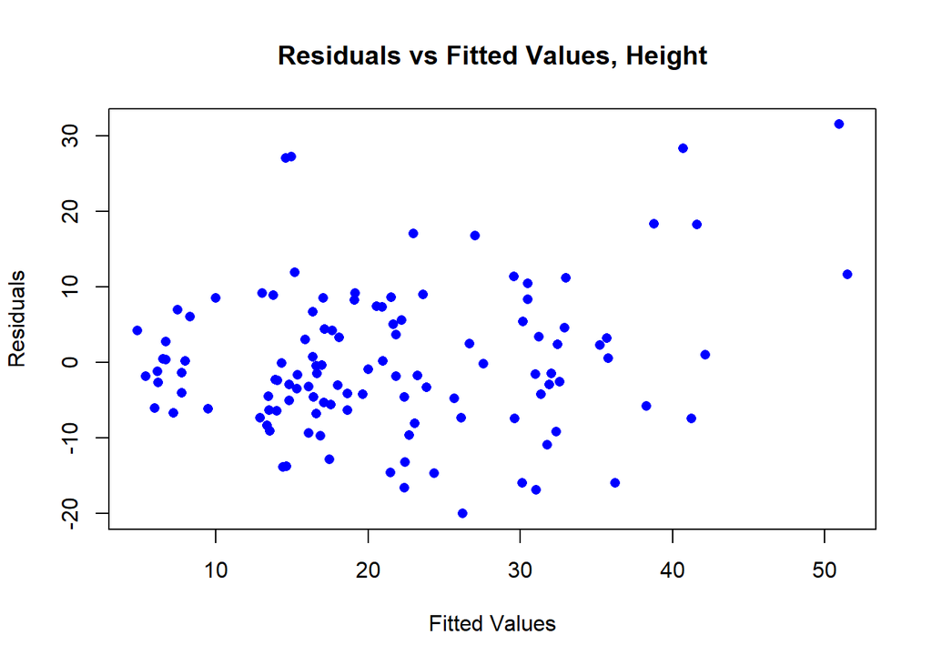

```r
# Calculate residuals
residuals_height <- residuals(lm_height)

#Calculate predicted
predicted_height <- predict(lm_height)

# Plot the ordinary residuals against the fitted values
plot(predicted_height, residuals_height,
     main = "Residuals vs Fitted Values, Height",
     xlab = "Fitted Values",
     ylab = "Residuals",
     pch = 16, col = "blue")
```

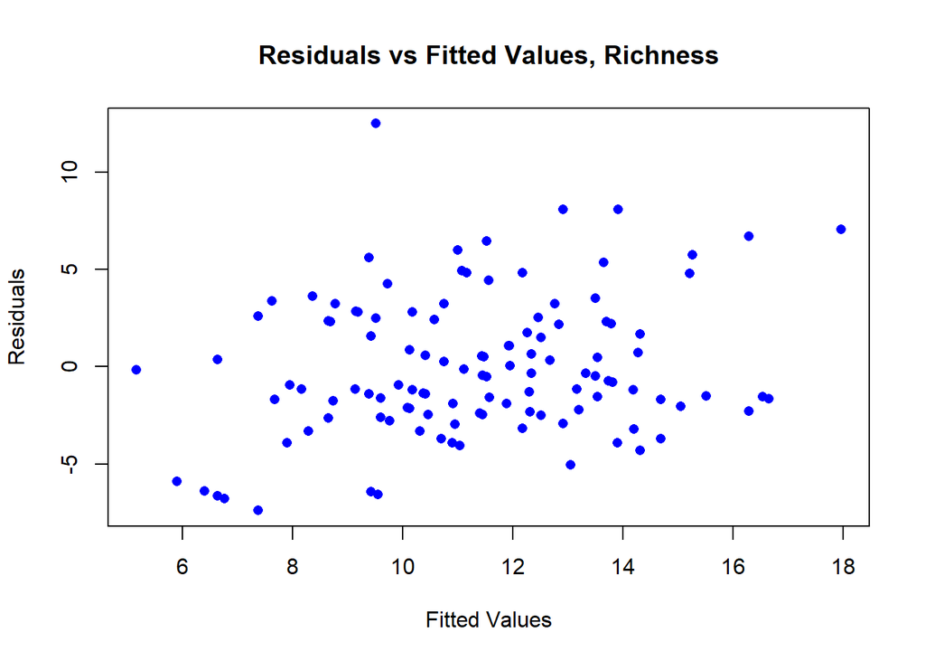

```r
# Calculate residuals
residuals_rich <- residuals(lm_rich)

#Calculate predicted
predicted_rich <- predict(lm_rich)

# Plot the ordinary residuals against the fitted values
plot(predicted_rich, residuals_rich,
     main = "Residuals vs Fitted Values, Richness",
     xlab = "Fitted Values",
     ylab = "Residuals",
     pch = 16, col = "blue")
```

Residuals versus fitted values do not indicate strong heteroskedasticity, with residual variance remaining relatively constant across the range of fitted values.

Finally let’s make a summary table of the LMM’s for the vegetation variables by management.

```r
# Tidy fixed effects tables for vegetation variable linear models
tidy_veg_models <- bind_rows(
  tidy(lm_cover,  effects = "fixed", conf.int = TRUE) %>% mutate(Response = "Vegetation cover (%)"),
  tidy(lm_height, effects = "fixed", conf.int = TRUE) %>% mutate(Response = "Vegetation height (cm)"),
  tidy(lm_rich,   effects = "fixed", conf.int = TRUE) %>% mutate(Response = "Vegetation richness")
) %>%
  dplyr::select(Response, term, estimate, std.error, statistic, p.value)


tidy_veg_models_fmt <- tidy_veg_models %>%
  mutate(
    estimate  = round(estimate, 2),
    std.error = round(std.error, 2),
    statistic = round(statistic, 2),
    p.value   = ifelse(p.value < 0.001, "<0.001", round(p.value, 3)),
  )

# save as table
write.csv(
  tidy_veg_models_fmt,
  here::here("02_tables", "veg_model_table.csv"),
  row.names = FALSE
)



# format nicely for word doc using flextable package
veg_table <- flextable(tidy_veg_models_fmt) %>%
  set_header_labels(
    Response   = "Response",
    term       = "Predictor",
    estimate   = "Estimate",
    std.error  = "SE",
    statistic  = "t value",
    p.value    = "p value"
  ) %>%
  autofit()

veg_table
```

| Response | Predictor | Estimate | SE | t value | p value |
| --- | --- | --- | --- | --- | --- |
| Vegetation cover (%) | (Intercept) | 35.99 | 4.43 | 8.12 | <0.001 |
| Vegetation cover (%) | management_typeorg | 29.43 | 4.60 | 6.40 | <0.001 |
| Vegetation cover (%) | habitatDR | 23.56 | 3.81 | 6.19 | <0.001 |
| Vegetation cover (%) | year2025 | -4.46 | 4.07 | -1.10 | 0.275 |
| Vegetation height (cm) | (Intercept) | 8.87 | 2.64 | 3.36 | 0.001 |
| Vegetation height (cm) | management_typeorg | 16.63 | 3.03 | 5.49 | <0.001 |
| Vegetation height (cm) | habitatDR | 0.53 | 1.97 | 0.27 | 0.787 |
| Vegetation height (cm) | year2025 | 8.64 | 2.17 | 3.97 | <0.001 |
| Vegetation richness | (Intercept) | 7.29 | 0.90 | 8.10 | <0.001 |
| Vegetation richness | management_typeorg | 2.27 | 0.98 | 2.31 | 0.028 |
| Vegetation richness | habitatDR | 2.74 | 0.72 | 3.81 | <0.001 |
| Vegetation richness | year2025 | 2.79 | 0.78 | 3.56 | <0.001 |

### 4.4 Check for collinearity

Let’s check to see if the vegetation variables are collinear.

```r
# Check collinearity among predictor vegetation variables
cor_matrix <- cor(veg[, c("avg_veg_height", "avg_veg_cover", "veg_richness")],
                  use = "complete.obs")
cor_matrix
```

```
##                avg_veg_height avg_veg_cover veg_richness
## avg_veg_height      1.0000000     0.3850983    0.3164754
## avg_veg_cover       0.3850983     1.0000000    0.5052215
## veg_richness        0.3164754     0.5052215    1.0000000
```

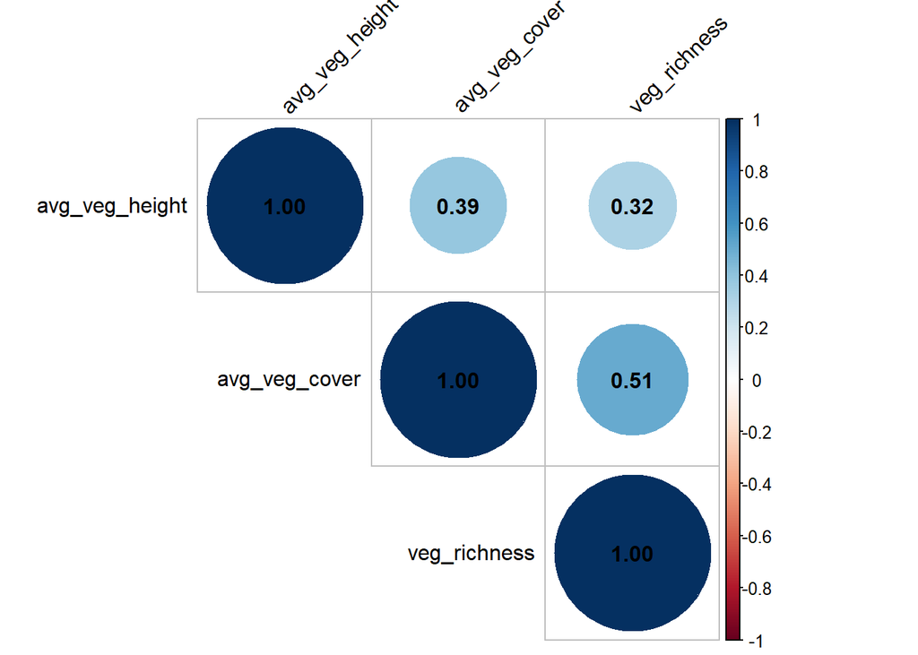

```r
# Plot the correlation matrix
corrplot(cor_matrix, method = "circle", type = "upper", order = "hclust",
         addCoef.col = "black", # Color of the correlation coefficients
         tl.col = "black", tl.srt = 45) # Color and rotation of the labels
```

The vegetation variables are moderately collinear (0.3-0.52), but below the 0.7 rule of thumb threshold. They can likely be modelled at individual predictors without causing problems.

### 4.5 Scaling predictor variables

Prior to modelling, let’s scale the continuous predictor variables to enable comparisons.

```r
# scale predictor variables
# simplify dataset to include only necessary variables
predictor_variables <- vineyard_sites_df %>%
  mutate(
    z_veg_height = scale(avg_veg_height),
    z_veg_cover = scale(avg_veg_cover),
    z_veg_richness = scale(veg_richness),
    z_total_natural_100 = scale(total_natural_100),
    z_total_natural_250 = scale(total_natural_250),
    z_total_natural_500 = scale(total_natural_500),
    z_total_natural_750 = scale(total_natural_750),
    z_total_natural_1000 = scale(total_natural_1000),
    z_distance_natural = scale(distance_to_natural)
  ) %>%
  dplyr::select(
    site_ID,
    year,
    habitat,
    management_type,
    avg_veg_height, avg_veg_cover, veg_richness, total_natural_100, total_natural_250, total_natural_500, total_natural_750, total_natural_1000, distance_to_natural,
    z_veg_height, z_veg_cover, z_veg_richness, z_total_natural_100, z_total_natural_250, z_total_natural_500, z_total_natural_750, z_total_natural_1000, z_distance_natural
  )
```

## 5 SPIDERS

### 5.1 Data import and summarizing

Let’s import the raw spider data and summarize by site/ habitat/ year. Let’s also calculate the total number of spiders collected in vineyards, and the number of different families. Note that spiders that could not be identified to family level, either due to damage or being juveniles, are included in total spider count but not in family richness count.

```r
# Load spider data
spider_VY_df <- read.csv(here::here("00_data","spider_VY_df.csv"))

# Summarize spider abundance by site_ID, habitat and year
spider_abundance_VY <- spider_VY_df %>%
  group_by(site_ID, habitat, year) %>%
  summarize(
    spider_abundance = sum(total_count, na.rm = TRUE),      # Sum, ignoring NAs
    trap_count = sum(!is.na(total_count)),         # Count of non-NA values
    .groups = "drop"
  )

# Total number of spiders found in vineyards across all sites and years
total_spiders_VY <- sum(spider_VY_df$total_count, na.rm = TRUE)

# VY FAMILY RICHNESS
# Define the full set of site and habitat combinations
site_habitat_all <- spider_VY_df %>%
  distinct(site_ID, habitat, year)

# Identify family columns
family_start <- which(names(spider_VY_df) == "family_richness") + 1
family_columns <- names(spider_VY_df)[family_start:ncol(spider_VY_df)]

# Then re-define unid and identified categories
unid_cols <- union("UNID.", "LYCOSIDAE..juvenile.")  # add the juveniles
family_columns <- setdiff(family_columns, unid_cols)

# Long format
spider_long_VY <- spider_VY_df %>%
  pivot_longer(all_of(family_columns), names_to = "spider_family", values_to = "count") %>%
  mutate(count = as.numeric(count))

# Get a list of all families observed at least once
observed_families_VY <- spider_long_VY %>%
  filter(count > 0) %>%
  distinct(spider_family) %>%
  arrange(spider_family)

# Total number of unique species across all vineyard sites and years
total_family_richness_VY <- spider_long_VY %>%
  filter(!is.na(count), count > 0) %>%
  distinct(spider_family) %>%
  nrow()

# Family richness per site × habitat × year (count only families with >0)
spider_richness_VY <- spider_long_VY %>%
  filter(!is.na(count), count > 0) %>%
  distinct(site_ID, habitat, year, spider_family) %>%
  count(site_ID, habitat, year, name = "family_richness")

# MERGE ABUNDANCE AND RICHNESS
# Merge the abundance and richness by site ID, habitat and year
# replace the one datapoint with family_richness of 0
spider_data_VY <- spider_abundance_VY %>%
  left_join(spider_richness_VY, by = c("site_ID", "habitat", "year")) %>%
  mutate(family_richness = replace_na(family_richness, 0))

cat("Total spiders in vineyards across all sites and years:", total_spiders_VY, "\n")
```

```
## Total spiders in vineyards across all sites and years: 5878
```

```r
cat("Total spider family richness across all vineyard sites and years:", total_family_richness_VY, "\n")
```

```
## Total spider family richness across all vineyard sites and years: 17
```

```r
print (observed_families_VY)
```

```
## # A tibble: 17 × 1
##    spider_family
##    <chr>
##  1 AGELENIDAE
##  2 AMAUROBIIDAE
##  3 CHEIRACANTHIIDAE
##  4 CORINNIDAE
##  5 DICTYNIDAE
##  6 GNAPHOSIDAE
##  7 LINYPHIIDAE
##  8 LYCOSIDAE
##  9 OXYOPIDAE
## 10 PHILODROMIDAE
## 11 PHOLCIDAE
## 12 PHRUROLITHIDAE
## 13 SALTICIDAE
## 14 THERIDIIDAE
## 15 THOMISIDAE
## 16 TITANOECIDAE
## 17 ZODARIIDAE
```

```r
cat("Number of site × habitat × year combinations:", nrow(spider_data_VY), "\n")
```

```
## Number of site × habitat × year combinations: 120
```

Now lets make some figures to explore the family abundance and site occupancy, as well as make a family accumulation curve to evaluate sampling effort.

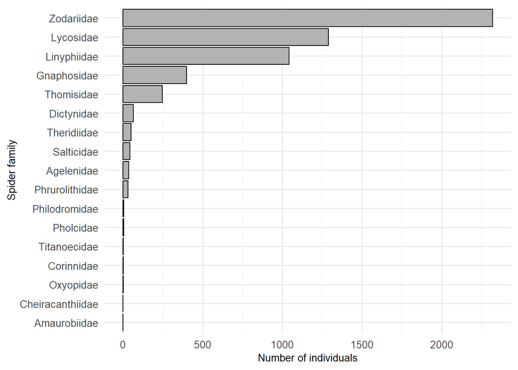

```r
# FAMILY ABUNDANCE AND SITE OCCUPANCY FIGURES
# Summarize total abundance per family
spider_family_VY_totals <- spider_long_VY %>%
  group_by(spider_family) %>%
  summarise(total_count = sum(count, na.rm = TRUE)) %>%
  filter(total_count > 0) %>%            # <-- only keep families with > 0 individuals
  arrange(desc(total_count)) %>%
  mutate(spider_family = factor(spider_family, levels = rev(spider_family)))

# Reorder factor levels for plotting
spider_family_VY_totals <- spider_family_VY_totals %>%
  mutate(spider_family = factor(spider_family, levels = rev(spider_family)))

# Abundance plot
spider_abund_vy <- spider_family_VY_totals %>%
  mutate(
    # Convert family names to title case
    spider_family = str_to_title(str_to_lower(spider_family)),
    # Reorder by abundance (most abundant at the top)
    spider_family = fct_reorder(spider_family, total_count, .desc = FALSE)
  ) %>%
  ggplot(aes(x = total_count, y = spider_family)) +
  geom_col(fill = "grey70", color = "black") +
  labs(
    x = "Number of individuals",
    y = "Spider family"
  ) +
  theme_minimal(base_size = 13) +
  theme(
    plot.title = element_blank(),
    axis.text.y  = element_text(size = 10),
    axis.text.x  = element_text(size = 10),
    axis.title.x = element_text(size = 10),
    axis.title.y = element_text(size = 10)
  )

#  Calculate site occupancy = number of unique sites where each family was detected in VY
spider_occupancy_VY <- spider_long_VY %>%
  filter(count > 0) %>%  # exclude zeros if present
  distinct(site_ID, spider_family) %>%
  count(spider_family, name = "site_occupancy") %>%
  arrange(desc(site_occupancy))

# Reorder factor levels for plotting
spider_occupancy_VY <- spider_occupancy_VY %>%
  mutate(spider_family = factor(spider_family, levels = rev(spider_family)))

# Occupancy plot
spider_occupancy_vy <- spider_occupancy_VY %>%
  mutate(
    # Convert to title case first
    spider_family = str_to_title(str_to_lower(spider_family))
  ) %>%
  # Then reorder by site occupancy (descending)
  mutate(
    spider_family = fct_reorder(spider_family, site_occupancy, .desc = FALSE)
  ) %>%
  ggplot(aes(x = site_occupancy, y = spider_family)) +
  geom_col(fill = "grey70", color = "black") +
  labs(
    x = "Sites detected",
    y = "Spider family"
  ) +
  theme_minimal(base_size = 13) +
  theme(
    plot.title = element_blank(),
    axis.text.y  = element_text(size = 10),
    axis.text.x  = element_text(size = 10),
    axis.title.x = element_text(size = 10),
    axis.title.y = element_text(size = 10)
  )

spider_abund_vy
```

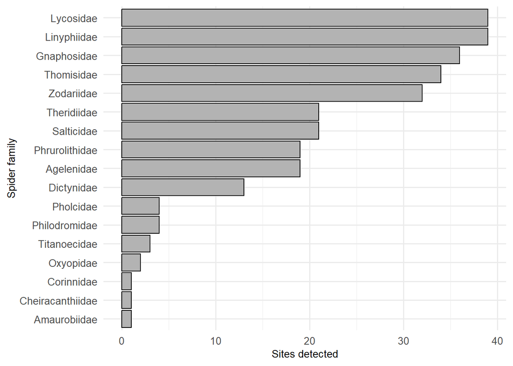

```r
spider_occupancy_vy
```

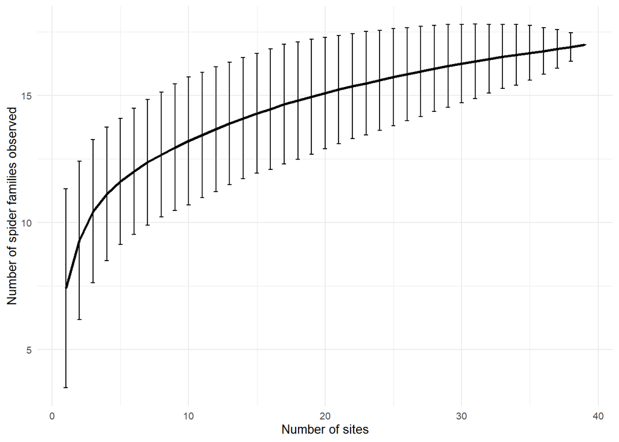

```r
# FAMILY ACCUMULATION CURVE
# Aggregate trap-level data to site-level totals
site_family_matrix <- spider_VY_df %>%
  group_by(site_ID) %>%
  summarise(across(all_of(family_columns), ~ sum(as.numeric(.), na.rm = TRUE))) %>%
  ungroup() %>%
  as.data.frame()

# Drop the site_ID column for the matrix
rownames(site_family_matrix) <- site_family_matrix$site_ID
site_family_matrix <- site_family_matrix[ , -1]

# Remove all-zero families
keep <- colSums(site_family_matrix, na.rm = TRUE) > 0
site_family_matrix <- site_family_matrix[, keep, drop = FALSE]

# Build accumulation curve
acc_site <- specaccum(site_family_matrix, method = "random", permutations = 1000)

# Prepare tidy dataframe for plotting
acc_site_df <- tibble(
  sites = acc_site$sites,
  richness = acc_site$richness,
  se = acc_site$sd
)

# Plot
spider_family_accumulation <- ggplot(acc_site_df, aes(x = sites, y = richness)) +
  geom_line(linewidth = 1) +
  geom_errorbar(aes(ymin = richness - 1.96 * se,
                    ymax = richness + 1.96 * se),
                width = 0.3) +
  labs(
    x = "Number of sites",
    y = "Number of spider families observed",
  ) +
  theme_minimal(base_size = 10)

spider_family_accumulation
```

Zodariidae was by far the most abundant family with over 2000 individuals, while Lycosidae was the second most abundant and occurred at the most sites.

The accumulation curve shows that spider family richness increases rapidly at first and then begins to level off, indicating that sampling effort was sufficient for capturing most families present in vineyards.

### 5.2 Descriptive stats

First let’s join the predictor variables to the spider response variables. Remove sites missing data (site 5 from 2024 was removed from analysis since the vines were pulled out, and site 36 was removed as it had just been replanted in 2025)

```r
# Full combined dataset (with predictor variables)
spider_data <- spider_data_VY %>%
  inner_join(predictor_variables, by = c("site_ID", "habitat", "year"))


# Remove incomplete rows (2 sites missing predictor variable data)
# convert others to factors
spider_df_clean <- spider_data %>%
  drop_na() %>%
  mutate(
    site_ID         = as.factor(site_ID),
    management_type = as.factor(management_type),
    habitat         = factor(habitat, levels = c("CR", "DR")),
    trap_count      = as.numeric(trap_count)
  )
```

Next let’s take a closer look at the response variables (spider abundance and family richness)

```r
# select spider abundance and family richness columns
spider_response_variables <- spider_df_clean %>%
  dplyr::select(
    spider_abundance,
    family_richness)

# Compute summary statistics
spider_summary <- as.data.frame(
  apply(spider_response_variables, 2, function(x){
    c(
      mean   = mean(x, na.rm = TRUE),
      sd     = sd(x, na.rm = TRUE),
      min    = min(x, na.rm = TRUE),
      max    = max(x, na.rm = TRUE),
      median = median(x, na.rm = TRUE),
      IQR    = IQR(x, na.rm = TRUE)
    )
  })
)

# Make rows readable
spider_summary
```

|  | spider_abundance | family_richness |
| --- | --- | --- |
| mean | 49.32759 | 5.232759 |
| sd | 48.57997 | 1.685528 |
| min | 0.00000 | 0.000000 |
| max | 261.00000 | 10.000000 |
| median | 33.00000 | 5.000000 |
| IQR | 40.25000 | 2.000000 |

Spider abundance averaged 49 individuals per habitat and sampling period, with counts ranging widely from 0 to 261 individuals. Spider family-level richness had a narrower range (0–10 families) and averaged five families per habitat and sampling period.

I also want to make summary tables for spiders by 1) management type, 2) habitat and 3) year

```r
# spider abundance and richness summary stats
response_summary_by <- function(data, group_var, group_label) {
  data %>%
    group_by({{ group_var }}) %>%
    summarise(
      spider_abundance_mean   = mean(spider_abundance,   na.rm = TRUE),
      spider_abundance_sd     = sd(spider_abundance,     na.rm = TRUE),
      spider_abundance_min    = min(spider_abundance,    na.rm = TRUE),
      spider_abundance_max    = max(spider_abundance,    na.rm = TRUE),
      spider_abundance_median = median(spider_abundance, na.rm = TRUE),
      spider_abundance_IQR    = IQR(spider_abundance,    na.rm = TRUE),

      spider_rich_mean        = mean(family_richness,    na.rm = TRUE),
      spider_rich_sd          = sd(family_richness,      na.rm = TRUE),
      spider_rich_min         = min(family_richness,     na.rm = TRUE),
      spider_rich_max         = max(family_richness,     na.rm = TRUE),
      spider_rich_median      = median(family_richness,  na.rm = TRUE),
      spider_rich_IQR         = IQR(family_richness,     na.rm = TRUE),
      .groups = "drop"
    ) %>%
    mutate(
      Level    = as.character({{ group_var }}),  # <-- force common type
      Grouping = group_label
    ) %>%
    dplyr::select(Grouping, Level, everything(), -{{ group_var }})
}


# 1) By management type
summary_by_mgmt <- response_summary_by(
  spider_df_clean,
  management_type,
  "Management type"
)

# 2) By habitat
summary_by_habitat <- response_summary_by(
  spider_df_clean,
  habitat,
  "Habitat"
)

# 3) By year
summary_by_year <- response_summary_by(
  spider_df_clean,
  year,
  "Year"
)

# Combine into one long table
response_summary_all <- bind_rows(
  summary_by_mgmt,
  summary_by_habitat,
  summary_by_year
)

response_summary_all
```

| Grouping | Level | spider_abundance_mean | spider_abundance_sd | spider_abundance_min | spider_abundance_max | spider_abundance_median | spider_abundance_IQR | spider_rich_mean | spider_rich_sd | spider_rich_min | spider_rich_max | spider_rich_median | spider_rich_IQR |
| --- | --- | --- | --- | --- | --- | --- | --- | --- | --- | --- | --- | --- | --- |
| Management type | conv | 31.54412 | 26.32486 | 0 | 157 | 22.5 | 26.00 | 4.852941 | 1.585990 | 0 | 8 | 5.0 | 2.00 |
| Management type | org | 74.52083 | 60.67001 | 7 | 261 | 58.5 | 52.50 | 5.770833 | 1.691526 | 3 | 10 | 5.0 | 2.25 |
| Habitat | CR | 49.94828 | 49.50684 | 0 | 219 | 31.5 | 39.50 | 5.327586 | 1.790697 | 0 | 10 | 5.0 | 2.00 |
| Habitat | DR | 48.70690 | 48.05954 | 5 | 261 | 33.0 | 39.50 | 5.137931 | 1.583337 | 2 | 9 | 5.0 | 2.00 |
| Year | 2024 | 41.88095 | 47.88666 | 0 | 219 | 26.5 | 29.75 | 4.404762 | 1.432370 | 0 | 7 | 4.0 | 1.00 |
| Year | 2025 | 53.55405 | 48.78416 | 11 | 261 | 41.0 | 44.75 | 5.702703 | 1.644665 | 2 | 10 | 5.5 | 2.00 |

```r
# save as table
write.csv(
  response_summary_all,
  here::here("02_tables", "spider_summary.csv"),
  row.names = FALSE
)
```

Spider abundance and richness higher in organic vineyards, but also lots of variability. Very similar between vine rows (CR) and inter rows (DR) Higher in 2025 compared to 2024.

### 5.3 Data Exploration

#### 5.3.1 Spider Abundance

Let’s explore the data prior to modelling.

First let’s look at the distribution of spider abundance using a histogram.

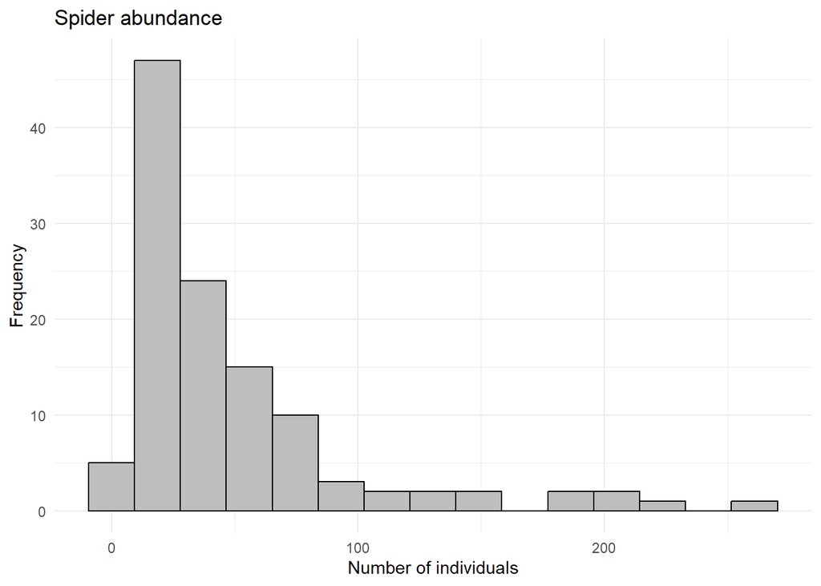

```r
# Visualize response variable distribution
spider_abund_histo <- ggplot(spider_df_clean, aes(x = spider_abundance)) +
  geom_histogram(bins = 15, fill = "grey", color = "black") +
  theme_minimal() +
  labs(title = "Spider abundance", x = "Number of individuals", y = "Frequency")

spider_abund_histo
```

Let’s also look at the difference between organic and conventional vineyards and sampling location using boxplots (just management) and lineplots (management and sampling location, lines represent the paired design)

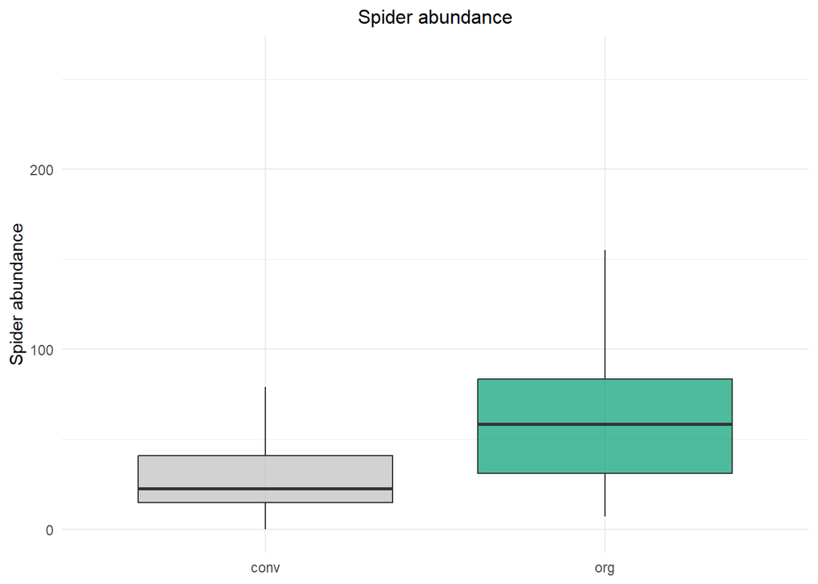

```r
# calculate abundance per trap
spider_VY <- spider_df_clean %>%
  mutate(
    abundance_per_trap = spider_abundance / trap_count
  )

# Define custom color palette for management type
mgmt_colors <- c("org" = "#009E73", "conv" = "grey")  # forest green and steel blue


# plot spider abundance per trap by management type
spider_abundance_management <- ggplot(
  spider_VY,
  aes(x = management_type, y = spider_abundance, fill = management_type)
) +
  geom_boxplot(alpha = 0.7, outlier.shape = NA) +
  theme_minimal() +
  scale_fill_manual(values = mgmt_colors, labels = c("conv" = "Conventional", "org" = "Organic")) +
  labs(
    title = "Spider abundance",
    x = NULL,                 # remove x-axis label
    y = "Spider abundance"
  ) +
  theme(
    legend.position = "none",
    plot.title = element_text(hjust = 0.5, size = 12)  # center title
  )

spider_abundance_management
```

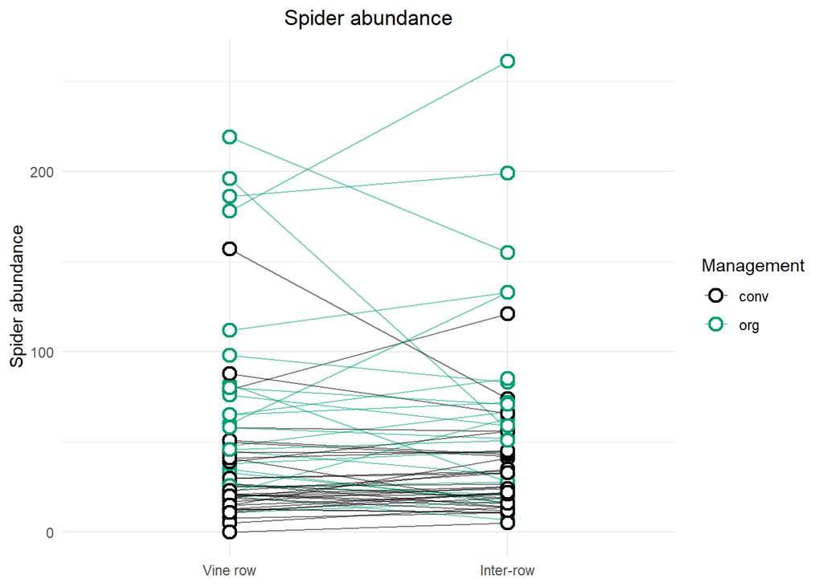

```r
# plot spider abundance per trap by management type and habitat
# let's use line plots to account for the paired design of vine rows/ interrows!
spider_abundance_habitat<- ggplot(spider_VY, aes(
  x = habitat,
  y = spider_abundance,
  group = interaction(site_ID, year),
  color = management_type
)) +
  geom_line(alpha = 0.5) +
  geom_point(
    aes(fill = management_type),
    shape = 21, size = 3, stroke = 1.2
  ) +
  scale_x_discrete(labels = c("CR" = "Vine row", "DR" = "Inter-row")) +
  scale_color_manual(values = c("conv" = "black", "org" = "#009E73")) +
  scale_fill_manual(values = c("conv" = "white", "org" = "white")) +
  labs(
    title = "Spider abundance",
    x = NULL,
    y = "Spider abundance",
    color = "Management",
    fill = "Management"
  ) +
  theme_minimal() +
  theme(plot.title = element_text(hjust = 0.5))

spider_abundance_habitat
```

Use scatterplots to look at spider abundance by the continuous predictor variables (vegetation complexity, proportion of natural areas in surrounding landscape etc.)

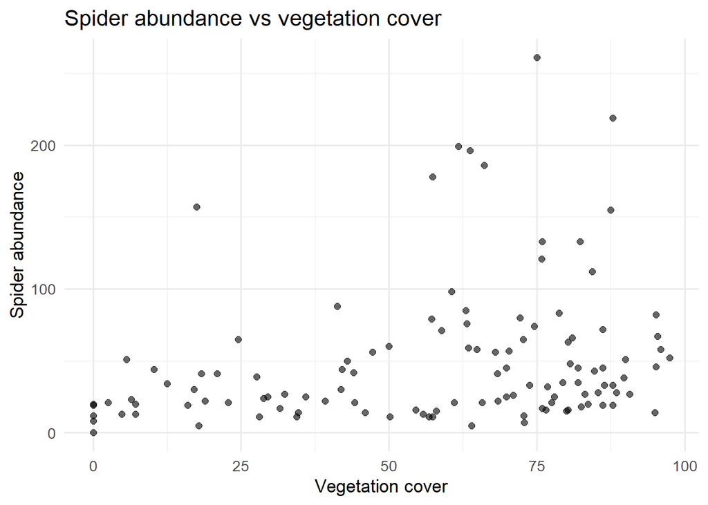

```r
# plot spider abundance by vegetation cover
ggplot(spider_df_clean, aes(x = avg_veg_cover, y = spider_abundance)) +
  geom_point(alpha = 0.6, size = 2) +
  labs(
    x = "Vegetation cover",
    y = "Spider abundance",
    title = "Spider abundance vs vegetation cover"
  ) +
  theme_minimal(base_size = 13)
```

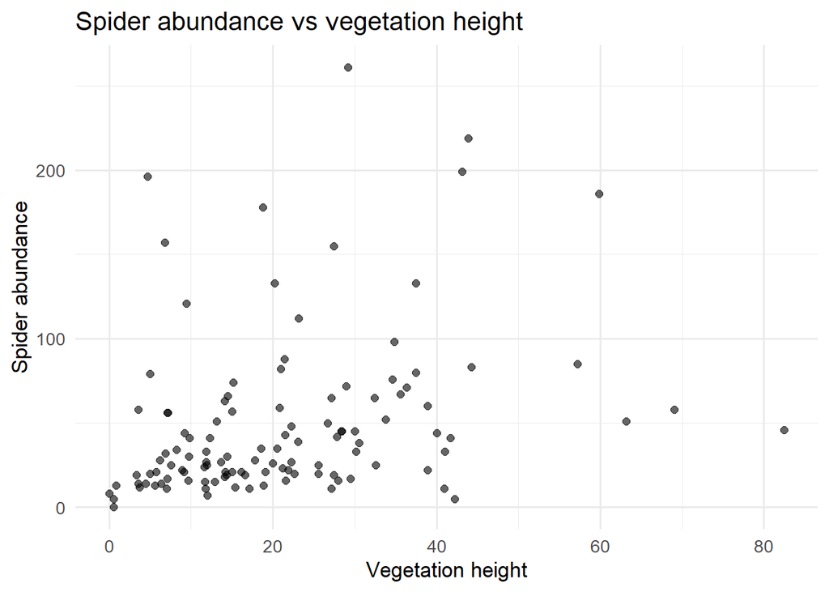

```r
# plot spider abundance by vegetation height
ggplot(spider_df_clean, aes(x = avg_veg_height, y = spider_abundance)) +
  geom_point(alpha = 0.6, size = 2) +
  labs(
    x = "Vegetation height",
    y = "Spider abundance",
    title = "Spider abundance vs vegetation height"
  ) +
  theme_minimal(base_size = 13)
```

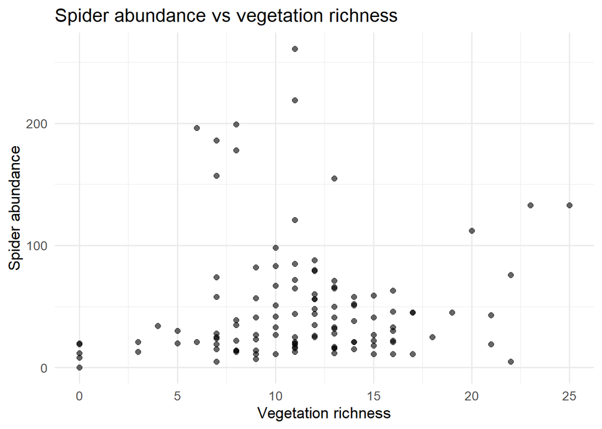

```r
# plot spider abundance by vegetation richness
ggplot(spider_df_clean, aes(x = veg_richness, y = spider_abundance)) +
  geom_point(alpha = 0.6, size = 2) +
  labs(
    x = "Vegetation richness",
    y = "Spider abundance",
    title = "Spider abundance vs vegetation richness"
  ) +
  theme_minimal(base_size = 13)
```

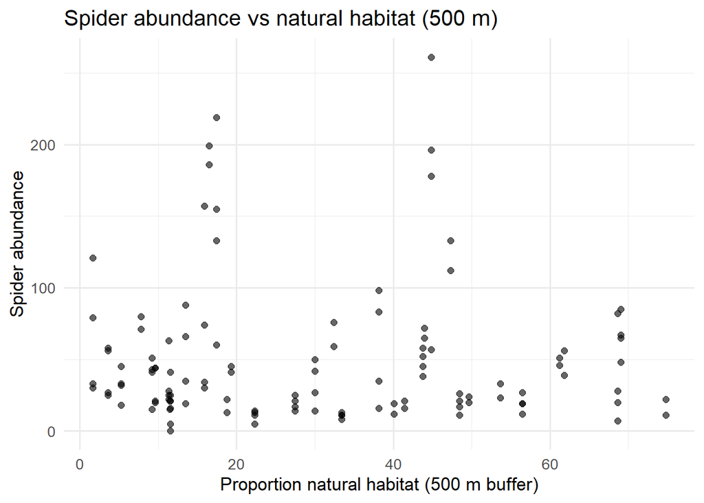

```r
# plot spider abundance by natural area (500m)
ggplot(spider_df_clean, aes(x = total_natural_500, y = spider_abundance)) +
  geom_point(alpha = 0.6, size = 2) +
  labs(
    x = "Proportion natural habitat (500 m buffer)",
    y = "Spider abundance",
    title = "Spider abundance vs natural habitat (500 m)"
  ) +
  theme_minimal(base_size = 13)
```

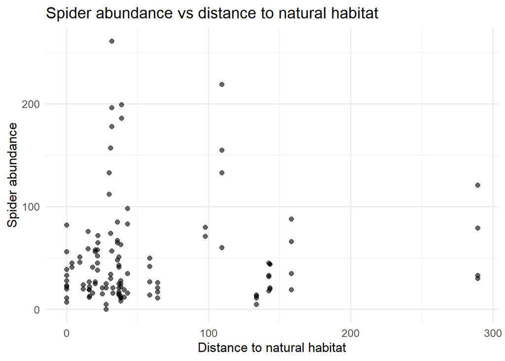

```r
# plot spider abundance by distance to natural area
ggplot(spider_df_clean, aes(x = distance_to_natural, y = spider_abundance)) +
  geom_point(alpha = 0.6, size = 2) +
  labs(
    x = "Distance to natural habitat",
    y = "Spider abundance",
    title = "Spider abundance vs distance to natural habitat"
  ) +
  theme_minimal(base_size = 13)
```

Spider abundance appears to increase with increasing vegetation height and cover, but no pattern with proportion natural areas in surrounding landscape.

#### 5.3.2 Spider Family Richness

Now we’ll do the same thing looking at spider family richness.

First let’s look at the histogram

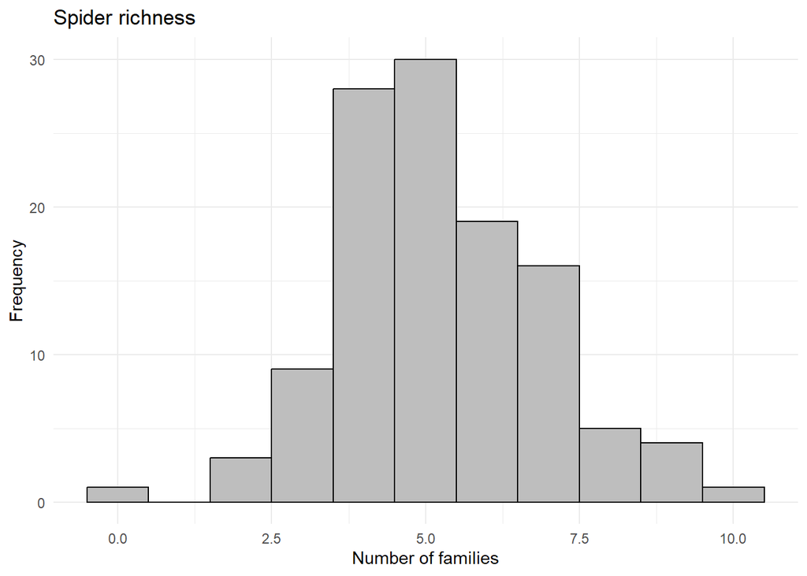

```r
# Histogram of spider family richness
spider_richness_histo <- ggplot(spider_df_clean, aes(x = family_richness)) +
  geom_histogram(binwidth = 1, fill = "grey", color = "black") +
  theme_minimal() +
  (labs(title = "Spider richness", x = "Number of families", y = "Frequency"))

spider_richness_histo
```

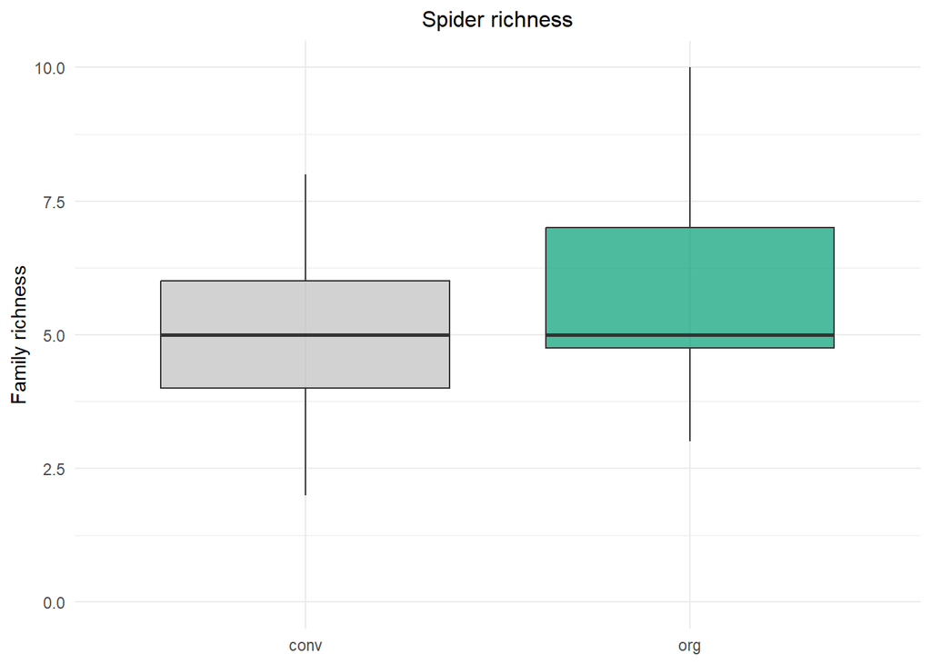

```r
# plot spider family richness per trap by management type
spider_richness_management <- ggplot(
  spider_VY,
  aes(x = management_type, y = family_richness, fill = management_type)
) +
  geom_boxplot(alpha = 0.7, outlier.shape = NA) +
  theme_minimal() +
  scale_fill_manual(values = mgmt_colors, labels = c("Conventional", "Organic")) +
  labs(
    title = "Spider richness",
    x = NULL,                 # remove x-axis label
    y = "Family richness"
  ) +
  theme(
    legend.position = "none",
    plot.title = element_text(hjust = 0.5, size = 12)  # center title
  )

spider_richness_management
```

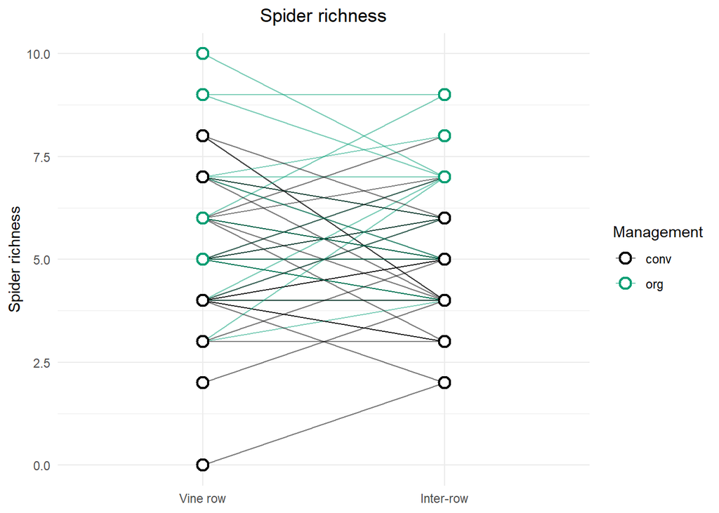

```r
# plot spider richness by management type and habitat
# let's use line plots to account for the paired design of vine rows/ interrows!
spider_richness_habitat <- ggplot(spider_VY, aes(
  x = habitat,
  y = family_richness,
  group = interaction(site_ID, year),
  color = management_type
)) +
  geom_line(alpha = 0.5) +
  geom_point(
    aes(fill = management_type),
    shape = 21, size = 3, stroke = 1.2
  ) +
  scale_x_discrete(labels = c("CR" = "Vine row", "DR" = "Inter-row")) +
  scale_color_manual(values = c("conv" = "black", "org" = "#009E73")) +
  scale_fill_manual(values = c("conv" = "white", "org" = "white")) +
  labs(
    title = "Spider richness",
    x = NULL,
    y = "Spider richness",
    color = "Management",
    fill = "Management"
  ) +
  theme_minimal() +
  theme(plot.title = element_text(hjust = 0.5))

spider_richness_habitat
```

pretty similar between conventional and organic management, and sampling locations

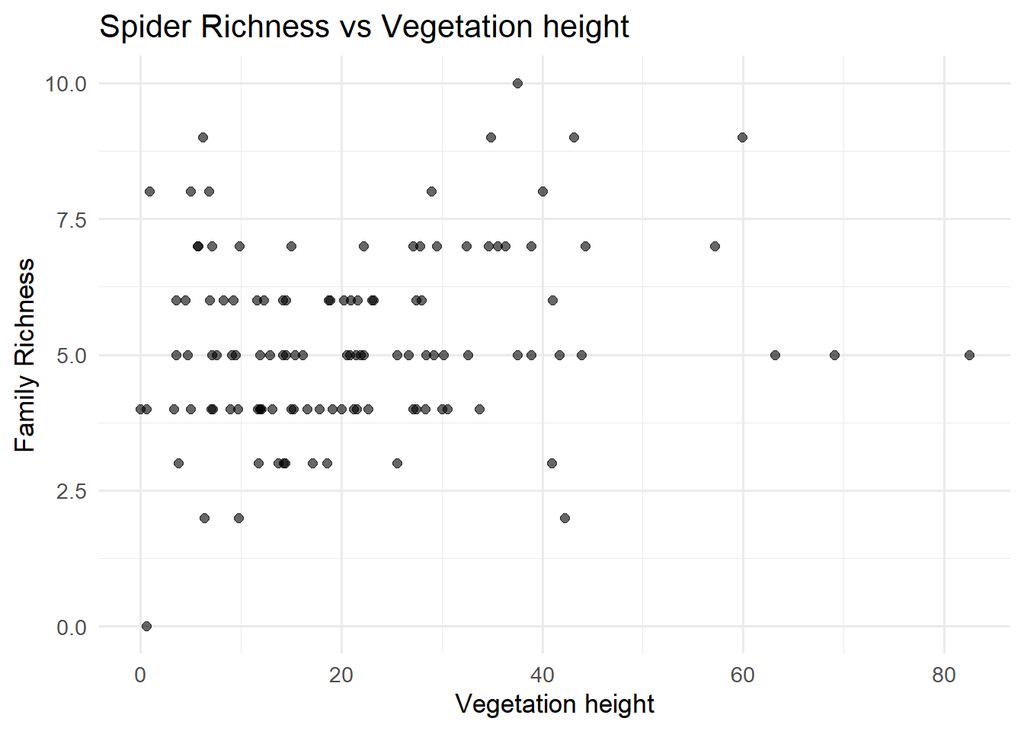

```r
# plot spider family richness by vegetation height
ggplot(spider_df_clean, aes(x = avg_veg_height, y = family_richness)) +
  geom_point(alpha = 0.6, size = 2) +
  labs(
    x = "Vegetation height",
    y = "Family Richness",
    title = "Spider Richness vs Vegetation height"
  ) +
  theme_minimal(base_size = 13)
```

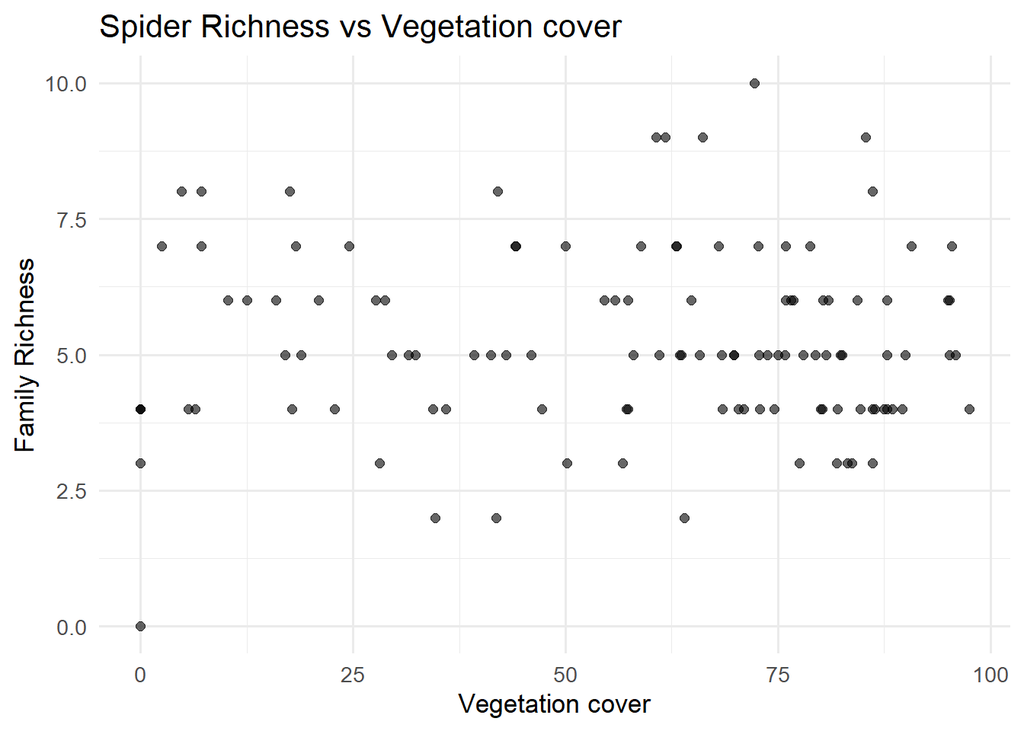

```r
# plot spider family richness by vegetation cover
ggplot(spider_df_clean, aes(x = avg_veg_cover, y = family_richness)) +
  geom_point(alpha = 0.6, size = 2) +
  labs(
    x = "Vegetation cover",
    y = "Family Richness",
    title = "Spider Richness vs Vegetation cover"
  ) +
  theme_minimal(base_size = 13)
```

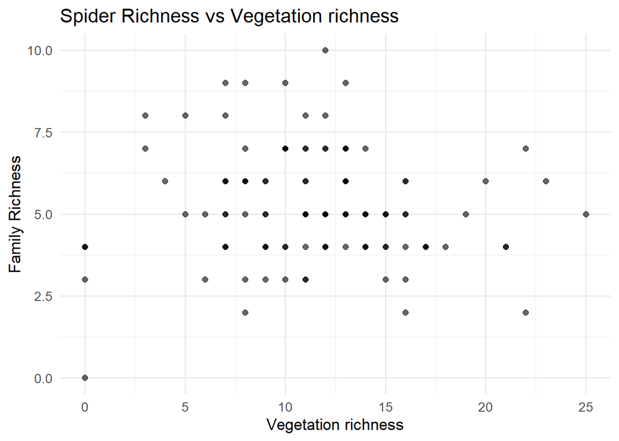

```r
# plot spider family richness by vegetation richness
ggplot(spider_df_clean, aes(x = veg_richness, y = family_richness)) +
  geom_point(alpha = 0.6, size = 2) +
  labs(
    x = "Vegetation richness",
    y = "Family Richness",
    title = "Spider Richness vs Vegetation richness"
  ) +
  theme_minimal(base_size = 13)
```

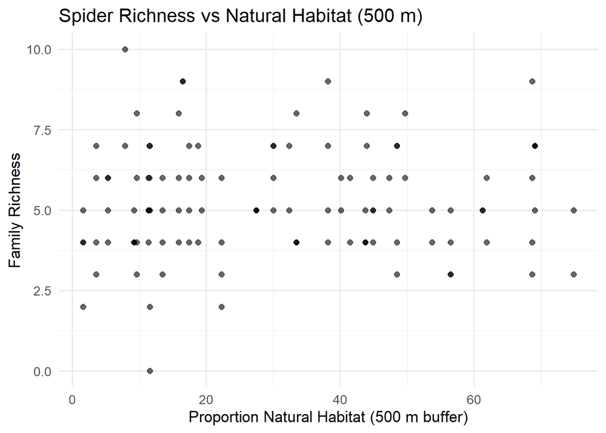

```r
# plot spider abundance by natural area (500m)
ggplot(spider_df_clean, aes(x = total_natural_500, y = family_richness)) +
  geom_point(alpha = 0.6, size = 2) +
  labs(
    x = "Proportion Natural Habitat (500 m buffer)",
    y = "Family Richness",
    title = "Spider Richness vs Natural Habitat (500 m)"
  ) +
  theme_minimal(base_size = 13)
```

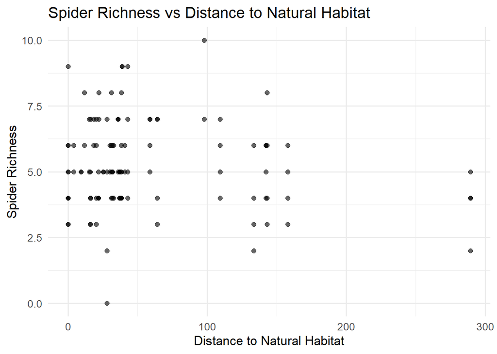

```r
# plot spider richness by distance to natural area (500m)
ggplot(spider_df_clean, aes(x = distance_to_natural, y = family_richness)) +
  geom_point(alpha = 0.6, size = 2) +
  labs(
    x = "Distance to Natural Habitat",
    y = "Spider Richness",
    title = "Spider Richness vs Distance to Natural Habitat"
  ) +
  theme_minimal(base_size = 13)
```

No obvious trends of spider family by the local and landscape continuous variables.

## 6 CARABIDS

### 6.1 Data import and summarizing

Let’s import the raw carabid data and summarize by site/ sampling location/ year. Let’s also calculate the total number of carabids collected in vineyards, and the number of different species.

```r
# Load raw carabid data
carabid_VY_df <- read.csv(here::here("00_data", "carabid_VY_df.csv"))

# Summarize carabid abundance by site_ID, habitat and year
carabid_abundance_VY <- carabid_VY_df %>%
  group_by(site_ID, habitat, year) %>%
  summarize(
    carabid_abundance = sum(total_abundance, na.rm = TRUE),      # Sum, ignoring NAs
    trap_count = sum(!is.na(total_abundance)),         # Count of non-NA values
    .groups = "drop"
  )

# Total number of carabids found in vineyards across all sites and years
total_carabids_VY <- sum(carabid_VY_df$total_abundance, na.rm = TRUE)

# Richness

# Identify species columns
species_start <- which(names(carabid_VY_df) == "species_richness") + 1
species_columns <- names(carabid_VY_df)[species_start:ncol(carabid_VY_df)]

# Split identified vs unidentified (for richness)
unid_cols <- intersect(species_columns, c("UNID","UNID."))
species_columns <- setdiff(species_columns, unid_cols)

# Long format
carabid_long_VY <- carabid_VY_df %>%
  pivot_longer(all_of(species_columns), names_to = "carabid_species", values_to = "count") %>%
  mutate(count = as.numeric(count))

# Get a list of all species observed at least once
observed_species_VY <- carabid_long_VY %>%
  filter(count > 0) %>%
  distinct(carabid_species) %>%
  arrange(carabid_species)

# species richness per site × habitat × year
carabid_richness_VY <- carabid_long_VY %>%
  filter(!is.na(count), count > 0) %>%
  distinct(site_ID, habitat, year, carabid_species) %>%
  count(site_ID, habitat, year, name = "species_richness")

# Merge abundance and richness summaries by site, year and habitat
carabid_data_VY <- carabid_abundance_VY %>%
  left_join(
    carabid_richness_VY,
    by = c("site_ID", "habitat", "year")
  ) %>%
  mutate(species_richness = replace_na(species_richness, 0))


# Total number of unique species across all vineyard sites and years
total_species_richness_VY <- carabid_long_VY %>%
  filter(!is.na(count), count > 0) %>%
  distinct(carabid_species) %>%
  nrow()


# Extract genus from species name and count unique genera
total_genus_richness_VY <- carabid_long_VY %>%
  filter(!is.na(count), count > 0) %>%
  mutate(genus = stringr::str_extract(carabid_species, "^[A-Za-z]+")) %>%
  distinct(genus) %>%
  nrow()


cat("Total carabids in vineyards across all sites and years:", total_carabids_VY, "\n")
```

```
## Total carabids in vineyards across all sites and years: 1144
```

```r
cat("Total carabid species richness across all vineyard sites and years:", total_species_richness_VY, "\n")
```

```
## Total carabid species richness across all vineyard sites and years: 31
```

```r
print(observed_species_VY)
```

```
## # A tibble: 31 × 1
##    carabid_species
##    <chr>
##  1 Agonoleptus_conjunctus
##  2 Agonum_placidum
##  3 Amara_aenea
##  4 Amara_apricaria
##  5 Amara_carinata
##  6 Amara_confusa
##  7 Amara_cupreolata
##  8 Amara_latior
##  9 Amara_littoralis
## 10 Amara_musculis
## # ℹ 21 more rows
```

```r
cat("Total carabid genus richness across all vineyard sites and years:", total_genus_richness_VY, "\n")
```

```
## Total carabid genus richness across all vineyard sites and years: 12
```

```r
cat("Number of site × habitat × year combinations:", nrow(carabid_data_VY), "\n")
```

```
## Number of site × habitat × year combinations: 118
```

Now let’s make some plots to look at abundance and site occupancy by genus, as well as species accumulation to evaluate sampling effort.

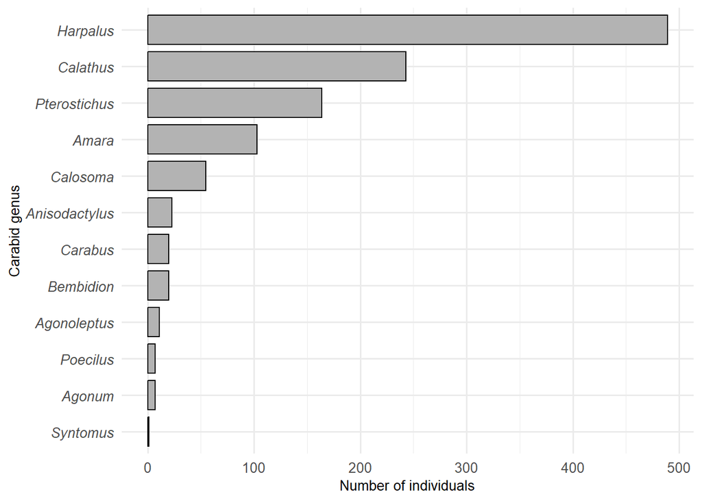

```r
# VY Site occupancy and species abundance plots
# Summarize total abundance per species
carabid_species_VY_totals <- carabid_long_VY %>%
  group_by(carabid_species) %>%
  summarise(total_abundance = sum(count, na.rm = TRUE)) %>%
  filter(total_abundance > 0) %>%
  arrange(desc(total_abundance)) %>%
  mutate(carabid_species = factor(carabid_species, levels = rev(carabid_species)))


# Genus totals & occupancy (VY)
carabid_long_genus_VY <- carabid_long_VY %>%
  mutate(genus = str_extract(carabid_species, "^[A-Za-z]+")) %>%  # extract genus
  group_by(site_ID, habitat, genus) %>%
  summarise(count = sum(count, na.rm = TRUE), .groups = "drop")

carabid_genus_totals_vy <- carabid_long_genus_VY %>%
  group_by(genus) %>%
  summarise(total_abundance = sum(count, na.rm = TRUE), .groups = "drop") %>%
  filter(total_abundance > 0) %>%  # remove genera with 0 abundance
  arrange(desc(total_abundance))

# create plot for abundance
genus_abund_vy <- carabid_genus_totals_vy %>%
  mutate(genus = forcats::fct_reorder(genus, total_abundance)) %>%
  ggplot(aes(x = total_abundance, y = genus)) +
  geom_col(fill = "grey70", color = "black", width = 0.8) +
  labs(
    x = "Number of individuals",
    y = "Carabid genus"
  ) +
  theme_minimal(base_size = 12) +
  theme(
    plot.title = element_blank(),                # remove title
    axis.title.x = element_text(size = 10),      # larger axis titles
    axis.title.y = element_text(size = 10),
    axis.text.y  = element_text(face = "italic", size = 10),  # italic + larger genus labels
    axis.text.x  = element_text(size = 10)
  )


# plot for occupancy
carabid_genus_occupancy_vy <- carabid_long_genus_VY %>%
  filter(count > 0) %>%
  distinct(site_ID, genus) %>%
  count(genus, name = "site_occupancy") %>%
  arrange(desc(site_occupancy))

genus_site_occupancy_vy <- carabid_genus_occupancy_vy %>%
  mutate(genus = forcats::fct_reorder(genus, site_occupancy)) %>%
  ggplot(aes(x = site_occupancy, y = genus)) +
  geom_col(fill = "grey70", color = "black", width = 0.8) +
  labs(
    x = "Sites detected",
    y = "Carabid genus"
  ) +
  theme_minimal(base_size = 12) +
  theme(
    plot.title = element_blank(),                # remove title
    axis.title.x = element_text(size = 10),      # larger axis titles
    axis.title.y = element_text(size = 10),
    axis.text.y  = element_text(face = "italic", size = 10),  # italic + larger genus labels
    axis.text.x  = element_text(size = 10)
  )


# plot
genus_abund_vy
```

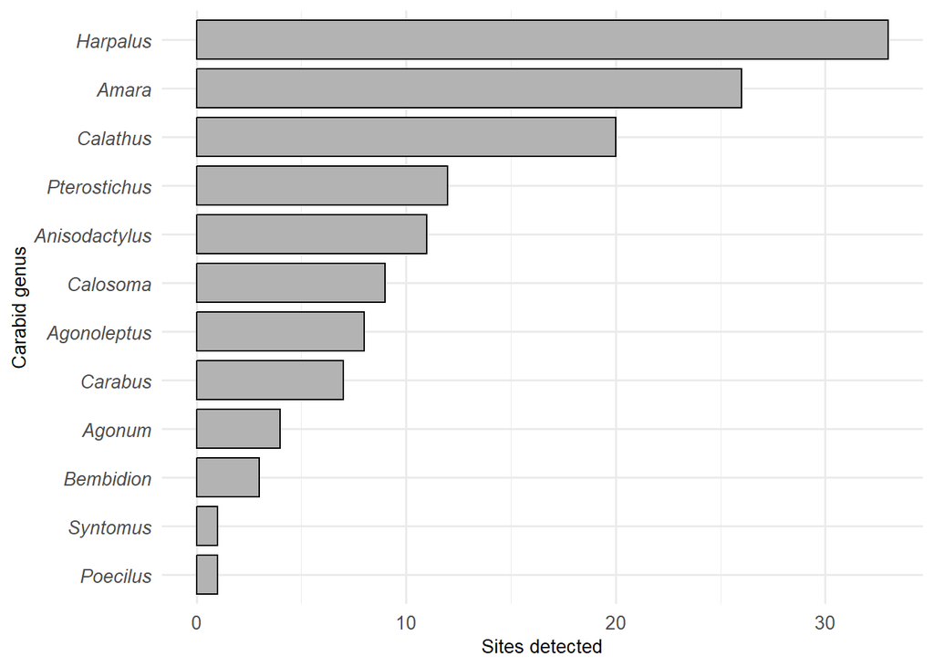

```r
genus_site_occupancy_vy
```

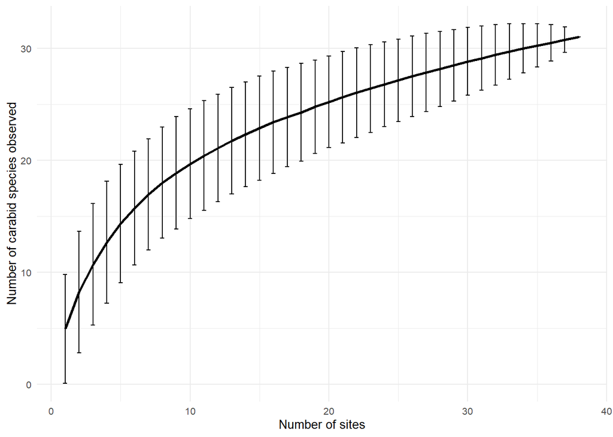

```r
# SPECIES ACCUMULATION CURVE
# Aggregate trap-level data to site-level totals
site_species_matrix <- carabid_VY_df %>%
  group_by(site_ID) %>%
  summarise(across(all_of(species_columns), ~ sum(as.numeric(.), na.rm = TRUE))) %>%
  ungroup() %>%
  as.data.frame()

# Drop the site_ID column for the matrix
rownames(site_species_matrix) <- site_species_matrix$site_ID
site_species_matrix <- site_species_matrix[ , -1]

# Remove all-zero families
keep <- colSums(site_species_matrix, na.rm = TRUE) > 0
site_species_matrix <- site_species_matrix[, keep, drop = FALSE]

# Build accumulation curve, use random as the method so sites are added randomly
acc_site <- specaccum(site_species_matrix, method = "random", permutations = 1000)

# Prepare tidy dataframe for plotting
acc_site_df <- tibble(
  sites = acc_site$sites,
  richness = acc_site$richness,
  se = acc_site$sd
)

# Plot
carabid_species_accumulation <- ggplot(acc_site_df, aes(x = sites, y = richness)) +
  geom_line(linewidth = 1) +
  geom_errorbar(aes(ymin = richness - 1.96 * se,
                    ymax = richness + 1.96 * se),
                width = 0.3) +
  labs(
    x = "Number of sites",
    y = "Number of carabid species observed") +
  theme_minimal(base_size = 10)

carabid_species_accumulation
```

Carabid species richness increased rapidly with the first few sites and continued to rise more gradually, without reaching an asymptotic, indicating that additional sampling may detect more species.

Lets join the predictor variables for the model.

```r
# Full combined dataset (with predictor variables)
carabid_df <- carabid_data_VY %>%
  inner_join(predictor_variables, by = c("site_ID", "habitat", "year"))

# Remove incomplete rows (sites missing predictor variable data)
# convert others to factors
carabid_df_clean <- carabid_df %>%
  drop_na() %>%
  mutate(
    management_type = as.factor(management_type),
    habitat         = factor(habitat, levels = c("CR", "DR")),
    site_ID         = as.factor(site_ID),
    trap_count      = as.numeric(trap_count),
    year = as.factor(year),
  )
```

### 6.2 Descriptive stats

```r
# select carabid abundance and species richness columns
vars_to_summarize <- carabid_df_clean %>%
  dplyr::select(
    carabid_abundance,
    species_richness)

# Keep only numeric variables for summary table
numeric_vars <- vars_to_summarize %>%
  dplyr::select(where(is.numeric))

# Compute summary statistics
carabid_summary <- as.data.frame(
  apply(numeric_vars, 2, function(x){
    c(
      mean   = mean(x, na.rm = TRUE),
      sd     = sd(x, na.rm = TRUE),
      min    = min(x, na.rm = TRUE),
      max    = max(x, na.rm = TRUE),
      median = median(x, na.rm = TRUE),
      IQR    = IQR(x, na.rm = TRUE)
    )
  })
)

# Make rows readable
carabid_summary
```

|  | carabid_abundance | species_richness |
| --- | --- | --- |
| mean | 9.586207 | 2.637931 |
| sd | 11.046990 | 1.776154 |
| min | 0.000000 | 0.000000 |
| max | 63.000000 | 8.000000 |
| median | 7.000000 | 2.000000 |
| IQR | 10.250000 | 3.000000 |

I also want to make summary tables for carabids by 1) management type, 2) habitat and 3) year

```r
# carabid abundance and richness summary stats
response_summary_by <- function(data, group_var, group_label) {
  data %>%
    group_by({{ group_var }}) %>%
    summarise(
      carabid_abundance_mean   = mean(carabid_abundance,   na.rm = TRUE),
      carabid_abundance_sd     = sd(carabid_abundance,     na.rm = TRUE),
      carabid_abundance_min    = min(carabid_abundance,    na.rm = TRUE),
      carabid_abundance_max    = max(carabid_abundance,    na.rm = TRUE),
      carabid_abundance_median = median(carabid_abundance, na.rm = TRUE),
      carabid_abundance_IQR    = IQR(carabid_abundance,    na.rm = TRUE),

      carabid_rich_mean        = mean(species_richness,    na.rm = TRUE),
      carabid_rich_sd          = sd(species_richness,      na.rm = TRUE),
      carabid_rich_min         = min(species_richness,     na.rm = TRUE),
      carabid_rich_max         = max(species_richness,     na.rm = TRUE),
      carabid_rich_median      = median(species_richness,  na.rm = TRUE),
      carabid_rich_IQR         = IQR(species_richness,     na.rm = TRUE),
      .groups = "drop"
    ) %>%
    mutate(
      Level    = as.character({{ group_var }}),
      Grouping = group_label
    ) %>%
    dplyr::select(Grouping, Level, everything(), -{{ group_var }})
}


# 1) By management type
summary_by_mgmt <- response_summary_by(
  carabid_df_clean,
  management_type,
  "Management type"
)

# 2) By habitat
summary_by_habitat <- response_summary_by(
  carabid_df_clean,
  habitat,
  "Habitat"
)

# 3) By year
summary_by_year <- response_summary_by(
  carabid_df_clean,
  year,
  "Year"
)

# Combine into one long table
carabid_response_summary_all <- bind_rows(
  summary_by_mgmt,
  summary_by_habitat,
  summary_by_year
)

carabid_response_summary_all
```

| Grouping | Level | carabid_abundance_mean | carabid_abundance_sd | carabid_abundance_min | carabid_abundance_max | carabid_abundance_median | carabid_abundance_IQR | carabid_rich_mean | carabid_rich_sd | carabid_rich_min | carabid_rich_max | carabid_rich_median | carabid_rich_IQR |
| --- | --- | --- | --- | --- | --- | --- | --- | --- | --- | --- | --- | --- | --- |
| Management type | conv | 8.102941 | 8.061591 | 0 | 39 | 6.0 | 9.25 | 2.764706 | 1.813034 | 0 | 8 | 3 | 2.25 |
| Management type | org | 11.687500 | 14.080553 | 0 | 63 | 7.5 | 14.00 | 2.458333 | 1.725384 | 0 | 7 | 2 | 2.00 |
| Habitat | CR | 11.000000 | 12.776074 | 0 | 63 | 7.5 | 11.50 | 2.810345 | 1.849200 | 0 | 8 | 3 | 2.00 |
| Habitat | DR | 8.172414 | 8.883531 | 0 | 43 | 5.5 | 9.75 | 2.465517 | 1.698457 | 0 | 7 | 2 | 2.00 |
| Year | 2024 | 5.238095 | 6.899309 | 0 | 37 | 3.0 | 6.75 | 2.238095 | 1.791709 | 0 | 7 | 2 | 2.00 |
| Year | 2025 | 12.054054 | 12.184531 | 0 | 63 | 8.5 | 12.00 | 2.864865 | 1.738558 | 0 | 8 | 3 | 2.00 |

```r
# save as table
write.csv(
  carabid_response_summary_all,
  here::here("02_tables", "carabid_summary.csv"),
  row.names = FALSE
)
```